# Data Visualization with ggplot2 (Part 1)

## Histograms

Histograms are one of the most common and intuitive ways of showing distributions. In this exercise you’ll use the `mtcars` data frame to explore typical variations of simple histograms. But first, some background:

The x axis/aesthetic: The documentation for `geom_histogram()` states the argument `stat = "bin"` as a default. Recall that histograms cut up a continuous variable into discrete bins - thats what the stat “bin” is doing. You always get 30 evenly-sized bins by default, which is specified with the default argument `binwidth = range/30`. This is a pretty good starting point if you don’t know anything about the variable being ploted and want to start exploring.

The y axis/aesthetic: `geom_histogram()` only requires one aesthetic: `x`. But there is clearly a `y` axis on your plot, so where does it come from? Actually, there is a variable mapped to the `y` aesthetic, it’s called `..count..`. When `geom_histogram()` executed the binning statistic (see above), it not only cut up the data into discrete bins, but it also counted how many values are in each bin. So there is an internal data frame where this information is stored. The `..` calls the variable count from this internal data frame. This is what appears on the y aesthetic. But it gets better! The density has also been calculated. This is the proportional frequency of this bin in relation to the whole data set. You use `..density..` to access this information.

INSTRUCTIONS

1 - Use the `mtcars` data frame and make a univariate histogram by mapping `mpg` onto the `x` aesthetic. Use `geom_histogram()` for the geom layer.

2 - Take plot 1 and manually create 1-unit wide bins with the `binwidth = 1` argument in `geom_histogram()`.

3 - Take plot 2, and map `..density..` onto the `y` aesthetic (i.e. inside an `aes()`) inside `geom_histogram()`. You’ll have two `aes()` functions: one inside `ggplot()` and another inside `geom_histogram()`. (See the intro text for a discussion of `..density..`).

4 - Take plot 3 and set the attribute `fill`, the inside of the bars, to the value `"#377EB8"` in `geom_histogram()`. This should not appear in `aes()`, since it’s an attribute, not an aesthetic mapping.

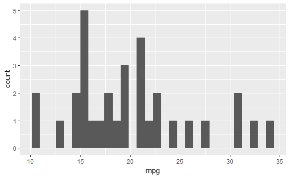

```r
# 1 - Make a univariate histogram
ggplot(mtcars, aes(x = mpg)) +
  geom_histogram()
```

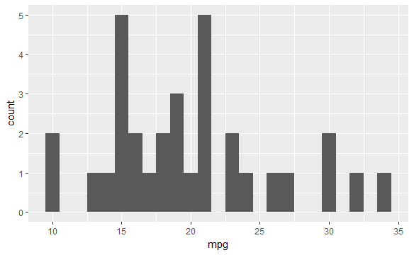

```r
# 2 - Plot 1, plus set binwidth to 1 in the geom layer
ggplot(mtcars, aes(x = mpg)) +
  geom_histogram(binwidth = 1)
```

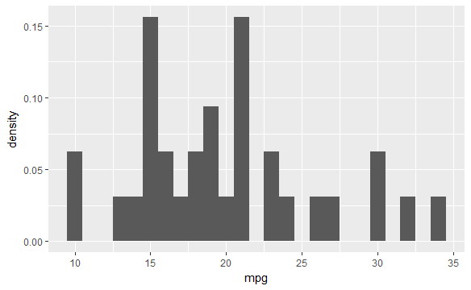

```r
# 3 - Plot 2, plus MAP ..density.. to the y aesthetic (i.e. in a second aes() function)
ggplot(mtcars, aes(x = mpg)) +
  geom_histogram(binwidth = 1, aes(y = ..density..))
```

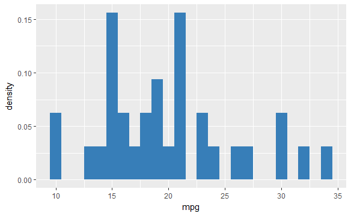

```r
# 4 - plot 3, plus SET the fill attribute to "#377EB8"
ggplot(mtcars, aes(x = mpg)) +
  geom_histogram(binwidth = 1, fill = "#377EB8", aes(y = ..density..))
```

## Position

In the previous chapter you saw that there are lots of ways to position scatter plots. Likewise, the `geom_bar()` and `geom_histogram()` geoms also have a `position` argument, which you can use to specify how to draw the bars of the plot.

Three `position` arguments will be introduced here:

- 1. `stack`: place the bars on top of each other. Counts are used. This is the default position.
- 2. `fill`: place the bars on top of each other, but this time use proportions.
- 3. `dodge`: place the bars next to each other. Counts are used.

In this exercise you’ll draw the total count of cars having a given number of cylinders (`cyl`), according to manual or automatic transmission type (`am`) - as shown in the viewer.

Since, in the built-in `mtcars` data set, `cyl` and `am` are integers, they have already been converted to factor variables for you.

INSTRUCTIONS

1 - Using `mtcars`, map `cyl` onto the `x` aesthetic and `am` onto `fill`. Use `geom_bar()` to make a bar plot.

2 - Take plot 1 and explicitly set `position = stack"` in `geom_bar()`. This doesn’t change anything, does it? It was mentioned above that `"stack"` is the default.

3 - Take plot 2 and set `position = "fill"` in `geom_bar()`.

4 - Take plot 3 and set `position = "dodge"` in `geom_bar()`.

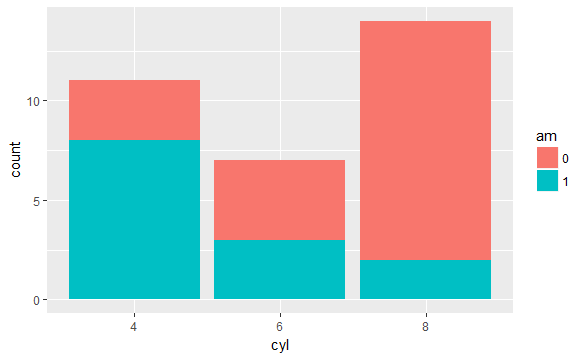

```r
# Draw a bar plot of cyl, filled according to am
ggplot(mtcars, aes(x = cyl, fill = am)) +
  geom_bar()
```

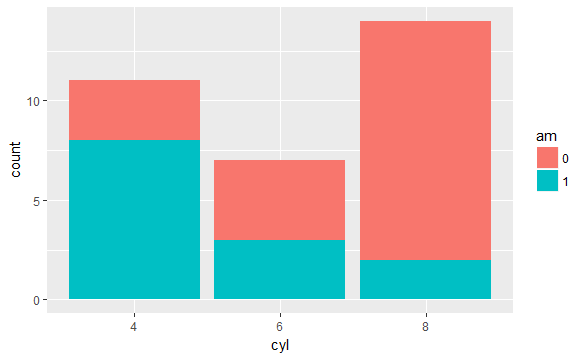

```r
# Change the position argument to stack
ggplot(mtcars, aes(x = cyl, fill = am)) +
  geom_bar(position = "stack")
```

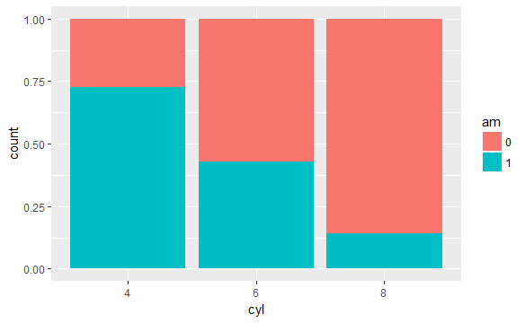

```r
# Change the position argument to fill
ggplot(mtcars, aes(x = cyl, fill = am)) +
  geom_bar(position = "fill")
```

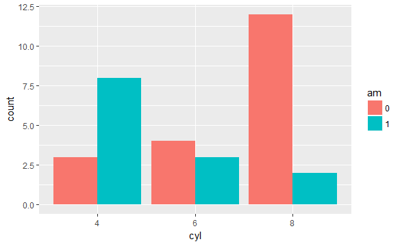

```r
# Change the position argument to dodge
ggplot(mtcars, aes(x = cyl, fill = am)) +
  geom_bar(position = "dodge")
```

## Overlapping bar plots

So far you’ve seen three different positions for bar plots: `stack` (the default), `dodge`(preferred), and `fill` (to show proportions).

However, you can go one step further by adjusting the dodging, so that your bars partially overlap each other. For this example you’ll again use the `mtcars` dataset. Like last time `cyl` and `am` are already available as factors inside `mtcars`.

Instead of using `position = "dodge"` you’re going to use `position_dodge()`, like you did with `position_jitter()` in the **Scatter plots and jittering (1)** exercise. Here, you’ll save this as an object, `posn_d`, so that you can easily reuse it.

Remember, the reason you want to use `position_dodge()` (and `position_jitter()`) is to specify how much dodging (or jittering) you want.

INSTRUCTIONS

1 - The last plot from the last exercise has been provided for you.

2 - Define a new object called `posn_d` by calling `position_dodge()` with the argument `width = 0.2`.

3 - Take plot 1 and make slightly overlapping bars by using the `position = posn_d` argument.

4 - Take plot 3 and `set alpha = 0.6` to see the overlap in bars.

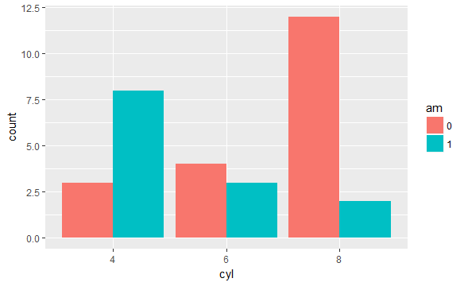

```r
# 1 - The last plot form the previous exercise
ggplot(mtcars, aes(x = cyl, fill = am)) +
  geom_bar(position = "dodge")
```

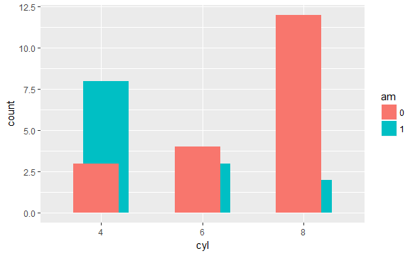

```r
# 2 - Define posn_d with position_dodge()
posn_d <- position_dodge(width = 0.2)
# 3 - Change the position argument to posn_d
ggplot(mtcars, aes(x = cyl, fill = am)) +
  geom_bar(position = posn_d)
```

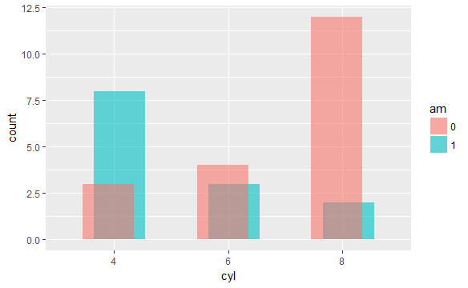

```r
# 4 - Use posn_d as position and adjust alpha to 0.6
ggplot(mtcars, aes(x = cyl, fill = am)) +
  geom_bar(position = posn_d, alpha = 0.6)
```

## Icon exercise interactive

Overlapping histograms pose similar problems to overlapping bar plots, but there is a unique solution here: a frequency polygon.

This is a geom specific to binned data that draws a line connecting the value of each bin. Like `geom_histogram()`, it takes a binwidth argument and by default `stat = "bin"` and `position = "identity"`.

INSTRUCTIONS

The code for a basic histogram of `mpg`, which you’ve already seen, is provided. Extend the code to map `cyl` onto `fill` inside `aes()`.

The default position for histograms is `"stack"`. Copy your solution to the first exercise and set the position for the histogram bars to `"identity"`.

Using the same data and base layers as in the previous two plots, create a plot with a `geom_freqpoly()`. Because you’re no longer working with bars, change the `aes()` function: `cyl` should be mapped onto `col`, not onto `fill`. This will correctly color the geom.

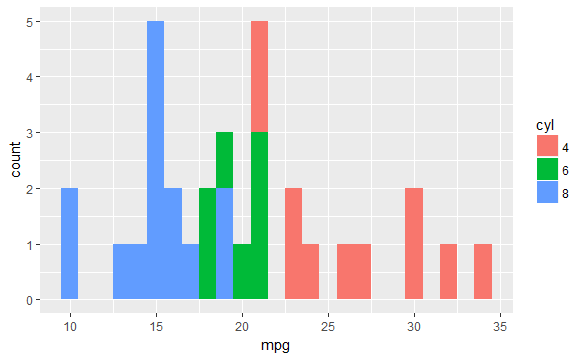

```r
# A basic histogram, add coloring defined by cyl
ggplot(mtcars, aes(mpg, fill = cyl)) +
  geom_histogram(binwidth = 1)
```

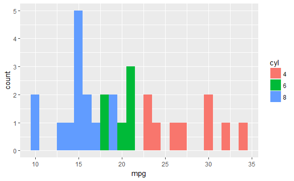

```r
# Change position to identity
ggplot(mtcars, aes(mpg, fill = cyl)) +
  geom_histogram(position = "identity", binwidth = 1)
```

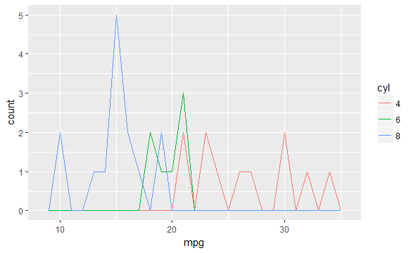

```r
# Change geom to freqpoly (position is identity by default)
ggplot(mtcars, aes(mpg, col = cyl)) +
  geom_freqpoly(position = "identity", binwidth = 1)
```

## Overlapping histograms

In this example of a bar plot, you’ll fill each segment according to an ordinal variable. The best way to do that is with a sequential color series.

You’ll be using the `Vocab` dataset from earlier. Since this is a much larger dataset with more categories, you’ll also compare it to a simpler dataset, `mtcars`. Both datasets are ordinal.

INSTRUCTIONS

The bar plot from the previous exercise is provided - `cyl` is on the x-axis and filled according to transmission type, `am`. Notice how you can set the color palette used to fill the bars with `scale_fill_brewer()`. For a full list of possible color sets, have a look at `?brewer.pal`.

Explore `Vocab` with `str()`. Notice that the `education` and `vocabulary` variables have already been converted to factor variables for you.

Make a filled bar chart with the Vocab dataset.

- Map `education` to `x` and `vocabulary` to `fill`.
- Inside `geom_bar()`, make sure to set position = “fill”`.

Allow color brewer to choose a default color palette by using the appropriate scale function, without arguments. Notice how this generates a warning message and an incomplete plot.

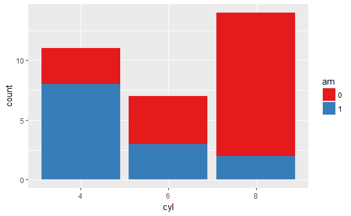

```r
Vocab <- Vocab %>%
  mutate(education = factor(education),
         vocabulary = factor(vocabulary))
# Example of how to use a brewed color palette
ggplot(mtcars, aes(x = cyl, fill = am)) +
  geom_bar() +
  scale_fill_brewer(palette = "Set1")
```

```r
# Use str() on Vocab to check out the structure
str(Vocab)
```

```
'data.frame':   30351 obs. of  4 variables:
 $ year      : num  1974 1974 1974 1974 1974 ...
 $ sex       : Factor w/ 2 levels "Female","Male": 2 2 1 1 1 2 2 2 1 1 ...
 $ education : Factor w/ 21 levels "0","1","2","3",..: 15 17 11 11 13 17 18 11 13 12 ...
 $ vocabulary: Factor w/ 11 levels "0","1","2","3",..: 10 10 10 6 9 9 10 6 4 6 ...
```

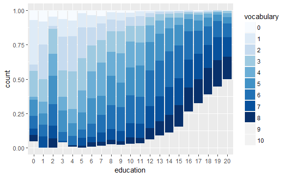

```r
# Plot education on x and vocabulary on fill
# Use the default brewed color palette
ggplot(Vocab, aes(x = education, fill = vocabulary)) +
  geom_bar(position = "fill") +
  scale_fill_brewer()
```

## Bar plots with color ramp, part 1

In the previous exercise, you ended up with an incomplete bar plot. This was because for continuous data, the default `RColorBrewer` palette that `scale_fill_brewer()` calls is `"Blues"`. There are only 9 colours in the palette, and since you have 11 categories, your plot looked strange.

In this exercise, you’ll manually create a color palette that can generate all the colours you need. To do this you’ll use a function called `colorRampPalette()`.

The input is a character vector of 2 or more colour values, e.g. `"#FFFFFF"` (white) and `"#0000FF"` (pure blue). (See **All about attributes, part 1** exercise for a discussion on hexadecimal codes).

The output is itself a function! So when you assign it to an object, that object should be used as a function. To see what we mean, execute the following three lines in the console:

```
new_col <- colorRampPalette(c("#FFFFFF", "#0000FF"))
new_col(4) # the newly extrapolated colours
munsell::plot_hex(new_col(4)) # Quick and dirty plot
```

`new_col()` is a function that takes one argument: the number of colours you want to extrapolate. You want to use nicer colours, so we’ve assigned the entire `"Blues"` colour palette from the `RColorBrewer` package to the character vector `blues`.

INSTRUCTIONS

1 - Like in the example code above, create a new function called `blue_range` that uses `colorRampPalette()` to extrapolate over all 9 values of the `blues` character vector.

2 - Take the plot code from the last exercise (provided), and change `scale_fill_brewer()` to be `scale_fill_manual()`. Set the argument `values = blue_range(11)` inside `scale_fill_manual()`.

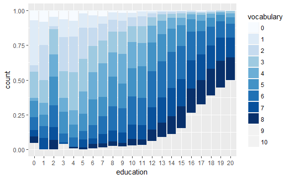

```r
# Final plot of last exercise
ggplot(Vocab, aes(x = education, fill = vocabulary)) +
  geom_bar(position = "fill") +
  scale_fill_brewer()
```

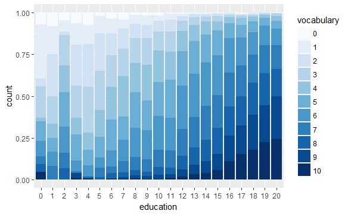

```r
# Definition of a set of blue colors
blues <- brewer.pal(9, "Blues") # from the RColorBrewer package
# 1 - Make a color range using colorRampPalette() and the set of blues
blue_range <- colorRampPalette(blues)
# 2 - Use blue_range to adjust the color of the bars, use scale_fill_manual()
ggplot(Vocab, aes(x = education, fill = vocabulary)) +
  geom_bar(position = "fill") +
  scale_fill_manual(values = blue_range(11))
```

## Bar plots with color ramp, part 2

As a last example of bar plots, you’ll return to histograms (which you now see are just a special type of bar plot). You saw a nice trick in a previous exercise of how to slightly overlap bars, but now you’ll see how to overlap them completely. This would be nice for multiple histograms, as long as there are not too many different overlaps!

You’ll make a histogram using the `mpg` variable in the `mtcars` data frame.

INSTRUCTIONS

1 - A basic histogram plot is provided.

2 - Take plot 1 and map `am` onto `fill` within the `aes()` function. The default position is `"stack"`.

3 - Take plot 2 and add the `position` argument within `geom_histogram()`. Set it to `"dodge"`.

4 - Take plot 3 and change the `position` argument to `"fill"`. In this case, none of these positions really work well, because it’s difficult to compare the distributions directly.

5 - Take plot 4 and change the position argument to `"identity"` and set `alpha = 0.4`. This produces overlapping bars.

6 - Take plot 5 and change the aesthetic mapping. Map `cyl` onto `fill`.

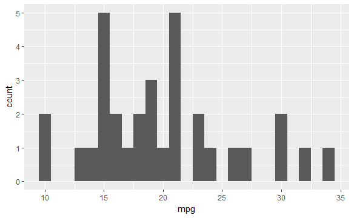

```r
# 1 - Basic histogram plot command
ggplot(mtcars, aes(mpg)) +
  geom_histogram(binwidth = 1)
```

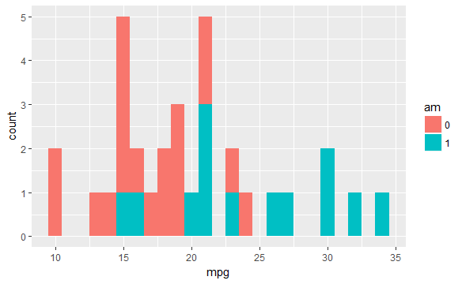

```r
# 2 - Plot 1, Expand aesthetics: am onto fill
ggplot(mtcars, aes(mpg, fill = am)) +
  geom_histogram(binwidth = 1)
```

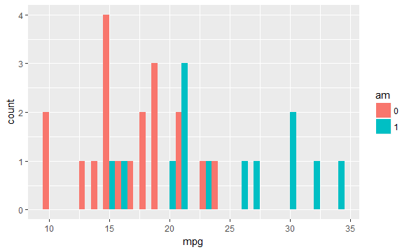

```r
# 3 - Plot 2, change position = "dodge"
ggplot(mtcars, aes(mpg, fill = am)) +
  geom_histogram(binwidth = 1, position = "dodge")
```

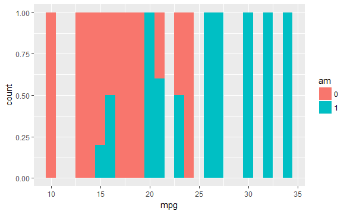

```r
# 4 - Plot 3, change position = "fill"
ggplot(mtcars, aes(mpg, fill = am)) +
  geom_histogram(binwidth = 1, position = "fill")
```

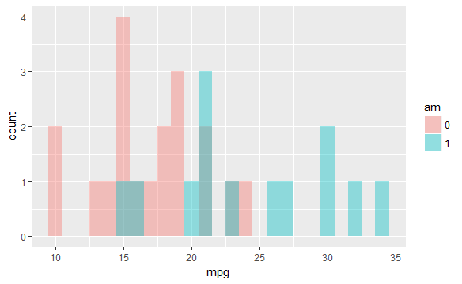

```r
# 5 - Plot 4, plus change position = "identity" and alpha = 0.4
ggplot(mtcars, aes(mpg, fill = am)) +
  geom_histogram(binwidth = 1, position = "identity", alpha = 0.4)
```

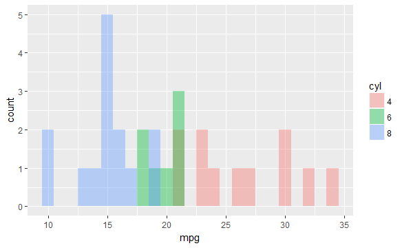

```r
# 6 - Plot 5, plus change mapping: cyl onto fill
ggplot(mtcars, aes(mpg, fill = cyl)) +
  geom_histogram(binwidth = 1, position = "identity", alpha = 0.4)
```

## Overlapping histograms (2)

In the video you saw how to make line plots using time series data. To explore this topic, you’ll use the `economics` data frame, which contains time series for unemployment and population statistics from the Federal Reserve Bank of St. Louis in the US. The data is contained in the `ggplot2` package.

To begin with, you can look at how the median unemployment time and the unemployment rate (the number of unemployed people as a proportion of the population) change over time.

In the next exercises, you’ll explore to how add embellishments to the line plots, such as recession periods.

INSTRUCTIONS

Print out the `head()` of the `economics` data frame.

Use the `economics` data frame to plot date on the x axis and `unemploy` on the y-axis. Use `geom_line()`.

Copy, paste and adjust the code for the previous instruction: instead of `unemploy`, plot `unemploy/pop` to represent the fraction of the total population that is unemployed.

```r
# Print out head of economics
head(economics)
```

| date | pce | pop | psavert | uempmed | unemploy |
| --- | --- | --- | --- | --- | --- |
| 1967-07-01 | 507.4 | 198712 | 12.5 | 4.5 | 2944 |
| 1967-08-01 | 510.5 | 198911 | 12.5 | 4.7 | 2945 |
| 1967-09-01 | 516.3 | 199113 | 11.7 | 4.6 | 2958 |
| 1967-10-01 | 512.9 | 199311 | 12.5 | 4.9 | 3143 |
| 1967-11-01 | 518.1 | 199498 | 12.5 | 4.7 | 3066 |
| 1967-12-01 | 525.8 | 199657 | 12.1 | 4.8 | 3018 |

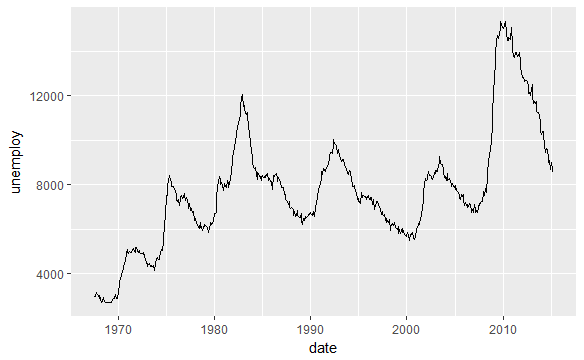

```r
# Plot unemploy as a function of date using a line plot
ggplot(economics, aes(x = date, y = unemploy)) +
  geom_line()
```

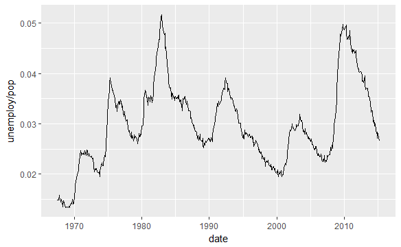

```r
# Adjust plot to represent the fraction of total population that is unemployed
ggplot(economics, aes(x = date, y = unemploy/pop)) +
  geom_line()
```

## Periods of recession

By themselves, time series often contain enough valuable information, but you always want to maximize the number of variables you can show in a plot. This allows you (and your viewers) to begin making comparisons between those variables that would otherwise be difficult or impossible.

Here, you’ll add shaded regions to the background to indicate recession periods. How do unemployment rate and recession period interact with each other?

In addition to the `economics` dataset from before, you’ll also use the `recess` dataset for the periods of recession. The `recess` data frame contains 2 variables: the `begin` period of the recession and the `end`. It’s already available in your workspace.

INSTRUCTIONS

Expand the command from the previous exercise with `geom_rect()`. You will use this geom layer to draw rectangles across the recession periods. There a few pitfalls here:

`geom_rect()` uses the recess dataset, so pass this directly as `data = recess` inside `geom_rect()`.

The `geom_rect()` command shouldn’t inherit aesthetics from the base `ggplot()` command it belongs to. It would result in an error, since you’re using a different dataset and it doesn’t contain `unemploy` or `pop`. That’s why you should specify `inherit.aes = FALSE` in `geom_rect()`.

`geom_rect()` needs four aesthetics: `xmin`, `xmax`, `ymin` and `ymax`. These should be set to `begin`, `end` and `-Inf`, `+Inf`, respectively. Define them within `aes()`.

The rectangles you add will be black and opaque by default. Set `fill` to `"red"` and `alpha` to `0.2` to improve this. Define them outside `aes()`.

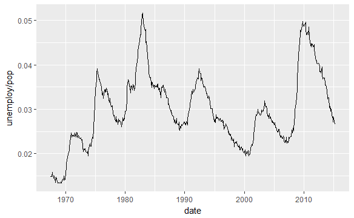

```r
# Basic line plot
ggplot(economics, aes(x = date, y = unemploy/pop)) +
  geom_line()
```

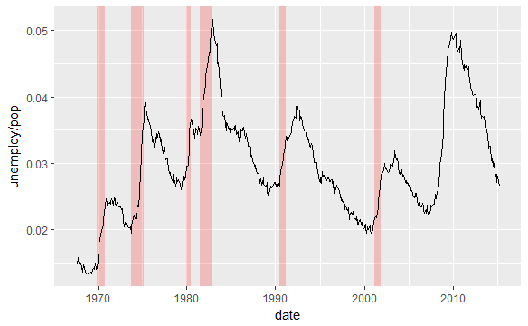

```r
# Expand the following command with geom_rect() to draw the recess periods
ggplot(economics, aes(x = date, y = unemploy/pop)) +
  geom_rect(data = recess,
         aes(xmin = begin, xmax = end, ymin = -Inf, ymax = +Inf),
         inherit.aes = FALSE, fill = "red", alpha = 0.2) +
  geom_line()
```

## Multiple time series, part 1

In the data chapter we discussed how the form of your data affects how you can plot it. Here, you’ll explore that topic in the context of multiple time series.

The dataset you’ll use contains the global capture rates of seven salmon species from 1950 - 2010.

In your workspace, the following dataset is available:

- `fish.species`: Each variable (column) is a Salmon `Species` and each observation (row) is one `Year`.

To get a multiple time series plot, however, both `Year` and `Species` should be in their own column. You need tidy data: one variable per column. Once you have that you can get the plot shown in the viewer by mapping `Year` to the x aesthetic and `Species` to the color aesthetic.

You’ll use the `gather()` function of the tidyr package, which is already loaded for you.

INSTRUCTIONS

Use `gather()` to move from `fish.species` to a tidy data frame, `fish.tidy`. This data frame should have three columns: `Year` (int), `Species` (factor) and `Capture` (int).

`gather()` takes four arguments: the original data frame (`fish.species`), the name of the key column (`Species`), the name of the value column (`Capture`) and the name of the grouping variable, with a minus in front (`-Year`). They can all be specified as object names (i.e. no `""`).

```r
# Check the structure as a starting point
str(fish.species)
```

```
'data.frame':   61 obs. of  8 variables:
 $ Year    : int  1950 1951 1952 1953 1954 1955 1956 1957 1958 1959 ...
 $ Pink    : int  100600 259000 132600 235900 123400 244400 203400 270119 200798 200085 ...
 $ Chum    : int  139300 155900 113800 99800 148700 143700 158480 125377 132407 113114 ...
 $ Sockeye : int  64100 51200 58200 66100 83800 72000 84800 69676 100520 62472 ...
 $ Coho    : int  30500 40900 33600 32400 38300 45100 40000 39900 39200 32865 ...
 $ Rainbow : int  0 100 100 100 100 100 100 100 100 100 ...
 $ Chinook : int  23200 25500 24900 25300 24500 27700 25300 21200 20900 20335 ...
 $ Atlantic: int  10800 9701 9800 8800 9600 7800 8100 9000 8801 8700 ...
```

```r
# Use gather to go from fish.species to fish.tidy
fish.tidy <- gather(fish.species, key = Species, value = Capture, group = -Year)
```

## Multiple time series, part 2

Now that you have tidy data, you’re ready to make your plot! The data frame `fish.tidy` is already available in the workspace, so you can start right away!

INSTRUCTIONS

Use `ggplot2` and everything you’ve learned to recreate the plot shown on the right.

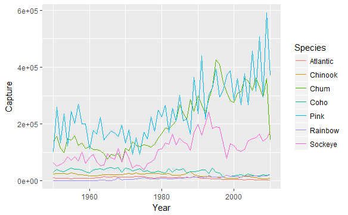

```r
# Recreate the plot shown on the right
ggplot(fish.tidy, aes(x = Year, y = Capture, color = Species)) +
  geom_line()
```

# Chapter 5: qplot and wrap-up

In this chapter you’ll learn about qplot; it is a quick and dirty form of ggplot2. It’s not as intuitive as the full-fledged ggplot() function but may be useful in specific instances. This chapter also features a wrap-up video and corresponding data visualization exercises.

## Using qplot

For simple exploratory plots, there are a variety of functions available. `ggplot2` offers a powerful and diverse array of functions, but `qplot()` allows for quick and dirty plots. Plus, you should also be familiar with basic plotting notation.

INSTRUCTIONS

Have a look at the base R plotting function. It plots `mpg` on the y-axis against `wt` on the x-axis. Create the same plot using `ggplot()`.

Create the same plot using `qplot()`.

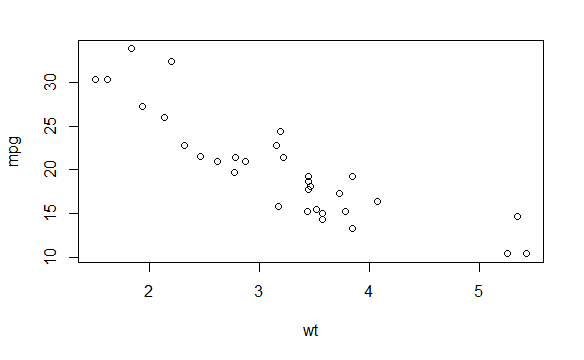

```r
# The old way (shown)
plot(mpg ~ wt, data = mtcars) # formula notation
```

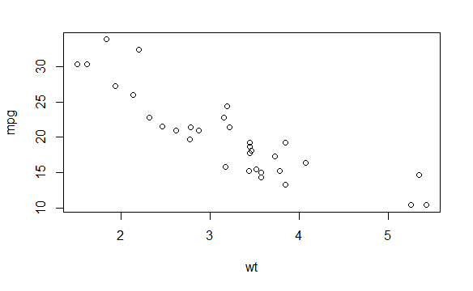

```r
with(mtcars, plot(wt, mpg)) # x, y notation
```

```r
# Using ggplot:
ggplot(mtcars, aes(x = wt, y = mpg)) +
  geom_point()
```

[output not shown]

```r
# Using qplot:
qplot(wt, mpg, data = mtcars)
```

[output not shown]